# Stat0009 ICA1 (2021)

# Introduction

## Plagiarism and collusion

Please familarize yourself with [the following excerpt on plagiarism and collusion from the student handbook](https://tsoo-math.github.io/ucl/Plagiarism-Collusion.pdf)

By ticking the submission declaration box in Moodle you are agreeing to the following declaration:

**Declaration:** I am aware of the UCL Statistical Science Department’s regulations on plagiarism for assessed coursework. I have read the guidelines in the student handbook and understand what constitutes plagiarism. I hereby affirm that the work I am submitting for this in-course assessment is entirely my own.

## Anonymous Marking

Please do **not** write your name anywhere on the submission. Please include only your **student number** as the proxy identifier.

# Questions

## 1.) Empirical distribution [10 points]

- Let $X_1, \ldots, X_n$ be i.i.d. random variables all with cdf $F$. Show that for every $x \in \mathbb{R}$, we have

$$\frac{1}{n} \sum_{i=1}^n \mathbf{1}[ X_i \leq x] \to F(x). \ \text{[5 points]}$$

- Demonstrate this fact by running simulations of a large number of random variables that are uniformly distributed in the unit interval $[0,1]$. [5 points]

## 2.) Generating random variables [10 points]

- Show that if $X$ is a continuous random variable taking values on $D$ with a cdf that is strictly increasing on $D$, then the random variable $F(X)$ is uniformly distributed on the unit interval $[0,1]$. [3 points]
- Show that if $U$ is uniformly distributed in $[0, \tfrac{\pi}{2}]$, then $\sin^2(U)$ has the beta distribution with parameters $(\tfrac{1}{2}, \tfrac{1}{2})$. [3 points]
- Suppose that you have access to a true source of randomization given by say radioactive decay; that is, you have access to independent random variables that are exponentially distributed with rate $1$. Show that you can generate random variables with the beta distribution with parameters $(\tfrac{1}{2}, \tfrac{1}{2})$. [2 points]
- Demonstrate your procedure in the last question, by computer simulations, and plot a histogram of the results against pdf of the beta $(\tfrac{1}{2}, \tfrac{1}{2})$. [2 points]

## 3.) Random walk [5 points]

Let $S_n = X_1 + \cdots + X_n$, where $X_i$ are i.i.d. random variables, with
$$\mathbb{P}(X_1 = 1) = \tfrac{1}{2} = \mathbb{P}(X_1 = -1).$$

Let
$$L_n = \# \{ 1 \leq k \leq n : S_k >0\}.$$
Demonstrate, by simulations, that $L_n/n$ converges in distribution to the beta $(\tfrac{1}{2}, \tfrac{1}{2})$ distribution.

## 4.) Exporting and importing data [5 points]

- Simulate $250$ random variables that are uniformly distributed in $[0,1]$.
- Export them to a tab delimited text file named *export.txt*.
- Now import them back and save them under the variable *imported*.
- Plot a probability histogram of the imported data. You may need to do some processing as the values may be in a table, rather than a vector.

## 5.) Estimating the stationary distribution [10 points]

- Suppose you are given the output of a $100000$ steps of a irreducible and aperiodic finite state Markov chain. Carefully explain how you could estimate the stationary distribution for this Markov chain, and why you estimator is reasonable. [5 points]
- Import the data from the file *markovchain.txt* and use this data and your method above to estimate the stationary distribution. [5 points]

## 6.) Poisson processes [10 points]

Suppose a shop that operates daily in the time interval $[a,b]$. It has customers arriving according to a Poisson process of intensity $3$ in the time interval $[a, c)$, and a Poisson process of intensity $5$ in the time interval $[c,b)$; here $a$ and $b$ are known, but $c$ is *unknown*. You can imagine the shop keeper notices that at some point in the day, the shop seems to get busier. The shop keeper has a log of all the arrival times, for each of $n$ days of operation, where $n$ is large.

- Given an open interval $(r,s) \subset [a,b]$, explain how you can use the shop keeper’s log to make a good guess at whether or not $(r,s)$ contains the unknown time $c$; show that as $n \to \infty$ you will know with certainty whether $c \in (r,s)$. Carefully explain your answer. [5 points]
- Demonstrate your answer by running simulations; for example, choose $a=0$, $b=8$, and $c=4$, and simulate the arrivals to generate the shop keeper’s log. Now apply your method with the intervals $(2.7, 4.3)$ and $(5,6)$. [5 points]

# Endnotes

- Version: 12 December 2021
- [Rmd Source](https://tsoo-math.github.io/ucl2/2021-ica1-stat9.Rmd)

# Solutions

## Empirical Distributions

- Fix $x \in \mathbb{R}$. We observe that the Bernoulli random variables $\mathbf{1}[X_i \leq x]$ are i.i.d. with mean $\mathbb{P}(X_i \leq x) = F(x)$. Thus the desired convergence is immediate from the law of large numbers.
- We will run our simulations in Python.

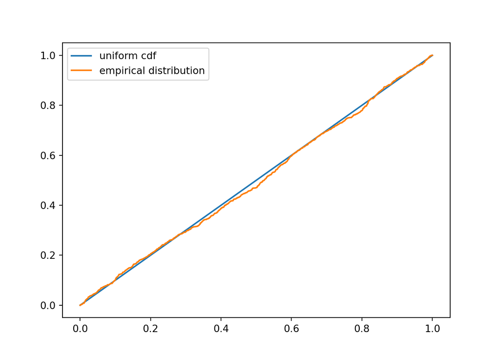

```python
import numpy as np

u = [np.random.uniform() for _ in range(1000)]
t = t=np.linspace(0,1,num=1000)
def emperical(x):
    return (1/len(u)) * sum(  k <= x for k in u)


import matplotlib.pyplot as plt
plt.plot(t,t, label='uniform cdf')
plt.plot(t,emperical(t), label='empirical distribution')
plt.legend(loc='upper left')
plt.show()
```

## Generating random variables

- Note that $F(X)$ takes values in $[0,1]$. Let $x \in [0,1]$, then $\{ F(X) \leq x \} = \{ X \leq F^{-1}(x)\}$. Thus
  $$\mathbb{P}(F(X) \leq x ) = \mathbb{P}(X \leq F^{-}(x)) = F( F^{-1}(x)) = x,$$
  as desired.
- Note that $\sin^2(U)$ takes values in $[0,1]$. For $x \in [0,1]$, we have
  $$\mathbb{P}(\sin^2(U) \leq x) =\mathbb{P}( U \leq \sin^{-1}(\sqrt{x}) = \frac{2}{\pi} \cdot \sin^{-1}(\sqrt{x});$$
  hence taking a derviative with respect to $x$, we obtain the pdf
  $$x \mapsto \frac{1}{\pi \sqrt{x(1-x)}},$$
  as desired.
- If $X$ is exponential, then we know that cdf is given by
  $$F(x) = 1 - e^{-x}.$$
  Thus the first part gives that $F(X)$ is uniformly distributed on $[0, 1]$, so that $\tfrac{\pi}{2} F(X)$ is uniformly distributed on $[0, \tfrac{\pi}{2}]$. Now the previous part gives that $\sin^2(\tfrac{\pi}{2} F(X))$ has the required beta distribution.
- We do our simulations in Python

```python
def F(x):
  return 1-np.exp(-x)

print(1+1)
```

```
## 2
```

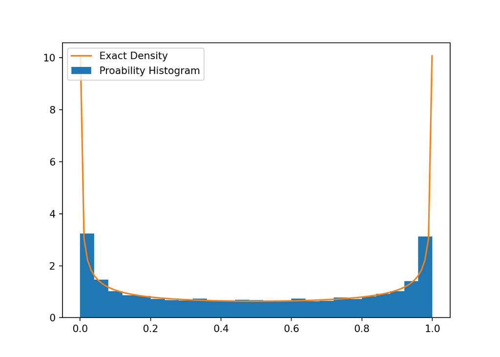

```python
x = np.random.exponential(size=10000)

trans = (np.sin((np.pi/2)*F(x)))**2

suppress=plt.hist(trans, bins = 25, density=True, label='Proability Histogram')
t=np.linspace(0.001,0.999,num=100)
plt.plot(t, 1/ (np.pi * np.sqrt(t*(1-t))), label='Exact Density')
plt.legend(loc='upper left')
plt.show()
```

## Random walk

We do our simulations in Python

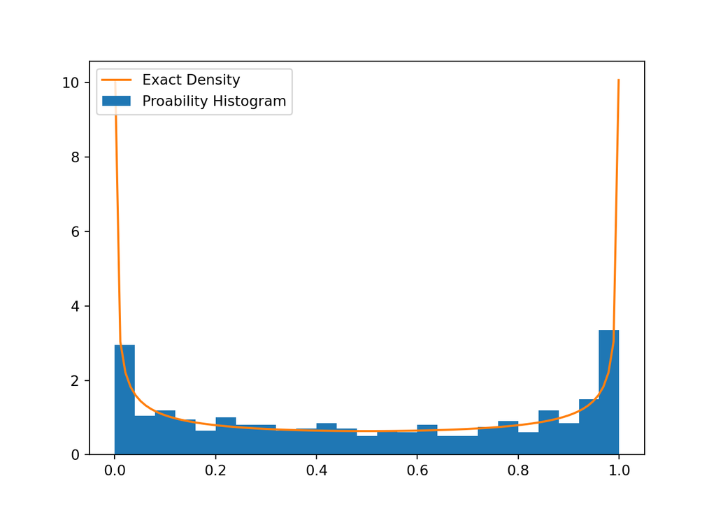

```python
def L(n):
  s=np.array([0])
  for i in range(n):
    x= 2*np.random.binomial(1,0.5,1)-1
    s = np.append(s, s[-1]+x)
  return sum(0<k for  k in s)

LL = [L(5000)/5000 for _ in range(500)]

suppress=plt.hist(LL, bins = 25, density=True, label='Proability Histogram')
t=np.linspace(0.001,0.999,num=100)
plt.plot(t, 1/ (np.pi * np.sqrt(t*(1-t))), label='Exact Density')
plt.legend(loc='upper left')
plt.show()
```

## Exporting and importing data

We will do this exercise in R.

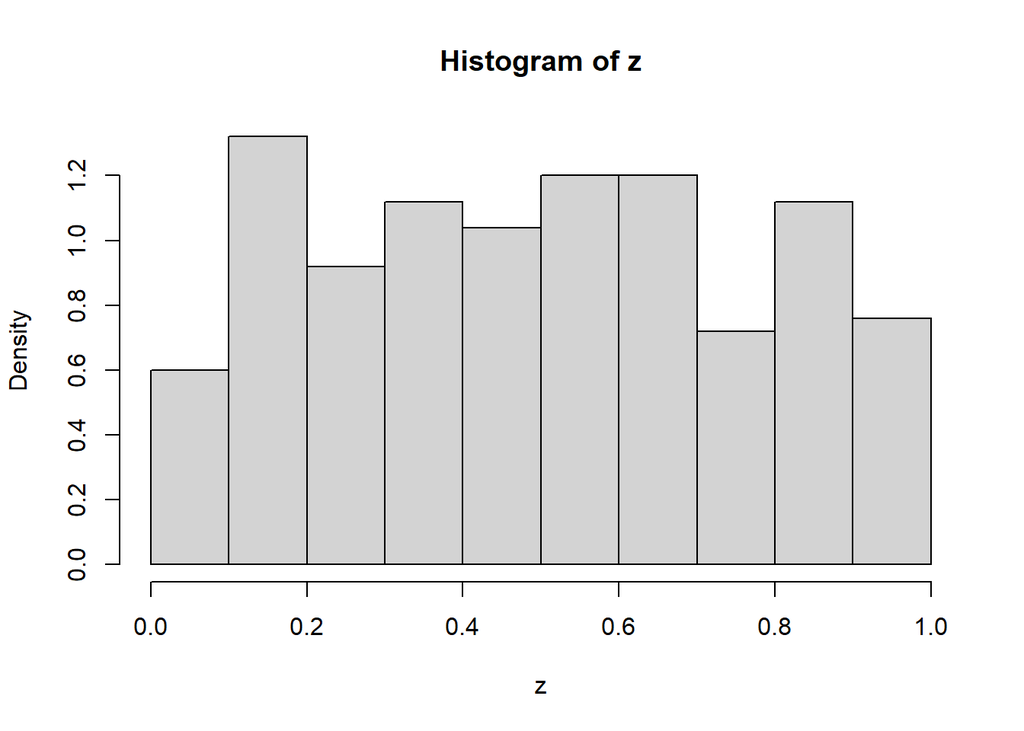

```r
x = runif(250)
write.table(x, "export.txt", sep=",")
imported =read.table("export.txt", sep=",")
z= imported[,]
hist(z, prob=TRUE)
```

## Estimating the stationary distribution

- Since the chain is on a finite state space and irreducible and aperiodic, it has a unique stationary distribution $\pi$, and we know that a version of the law of large numbers gives that for every state $s$, we have

$$\frac{1}{n} \sum_{i=1}^n \mathbf{1}[X_i = s] \to \pi(s).$$
Thus for each state, we simply need to count the number of occurrences and divide by $100000$, to get its approximate probability under $\pi$.

- A quick scan of the file shows there are $4$ states: $1,2,3,4$. With R, we have:

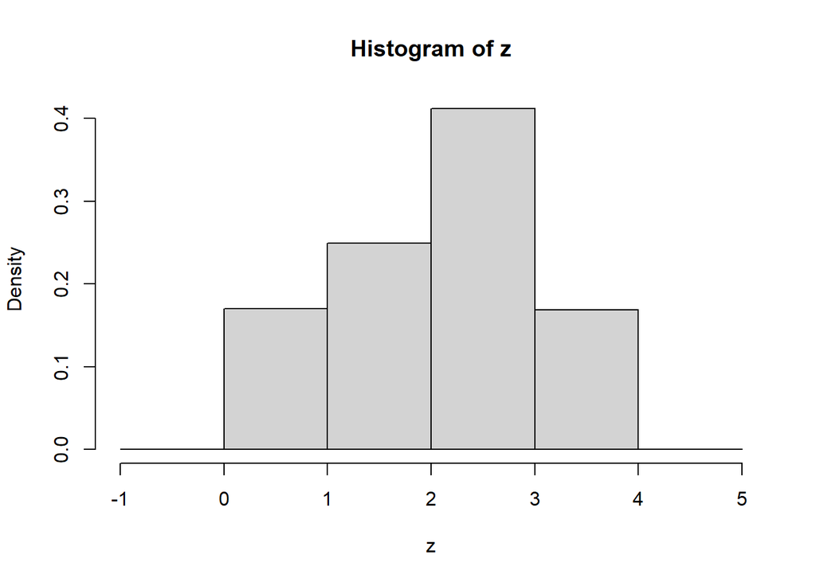

```r
z =read.table("markovchain.txt", sep=",")
z= z[,]

b1 = seq(-1,5, by=1)
hist(z, prob=TRUE, breaks=b1)
```

```r
sum(z==1)/100000
```

```
## [1] 0.17023
```

```r
sum(z==2)/100000
```

```
## [1] 0.24957
```

```r
sum(z==3)/100000
```

```
## [1] 0.41172
```

```r
sum(z==4)/100000
```

```
## [1] 0.16849
```

## Poisson processes

- First, suppose that $(r,s)$ does not contain the point $c$, then the Poisson process restricted to the time interval $[r,s]$ has either intensity $3$ or intensity $5$, for the whole time interval $(r,s)$. If we let $X_i$ be the number of arrivals in the time interval $(r,s)$ for each log entry $i$, then we know that $X_i$ is a Poisson random variable with mean $\lambda(s-r)$, where $\lambda$ is either $3$ or $5$. Assuming the log entries are independent, then the law of large numbers gives that

$$\frac{1}{n} \sum_{i=1} ^n X_i \to \mathbb{E} X_1 = \lambda(s-r);$$

Similarly, if $(r,s)$ does contain the point $c$, then it is not difficult to argue that $X_i$ has mean $3(c-r) + 5(s-c)$, and the law of large numbers again will detect this; in particular, we have the convergence

$$\frac{1}{(s-r)n} \sum_{i=1} ^n X_i \to \lambda;$$

if $\lambda \in (3,5)$, then the interval contains $c$, and if $\lambda \in \{3,5\}$, it does not contain $c$.

```r
arr <- function(end,intensity){
T = rexp(1,intensity)
while(T[length(T)] < end){
  T <- c(T,  (T[length(T)] + rexp(1,intensity))  )
}
T <- T[-length(T)]   # remove the last arrival, as it will have past the end
T
}

record <- function(){
  first=arr(4,3)
  second=4+arr(4,5)
  c(first, second)
}

counts <- function(r,s){
  x = record()
  sum( r < x & x< s)

}

z=replicate(10000, counts(2.7, 4.3))
mean(z)/(4.3-2.7)
```

```
## [1] 3.360375
```

```r
z=replicate(10000, counts(5, 6))
mean(z)/(6-5)
```

```
## [1] 4.9778
```

- End of Solutions